# Reproducible Research: Peer Assessment 1

## Loading and preprocessing the data

First, we load the packages and data for the analysis:

```r
library(ggplot2)
setwd("..")
setwd("RepData_PeerAssessment1")

z <- "activity.zip"
c <- "activity.csv"
if(!file.exists(c)){
        unzip(z)
}

d <- read.csv(c)
```

## What is mean total number of steps taken per day?

```
## stat_bin: binwidth defaulted to range/30. Use 'binwidth = x' to adjust this.
```

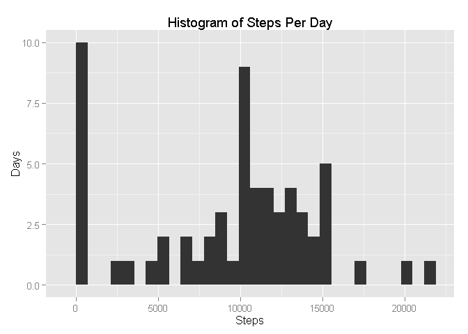

```r
dStepsPerDay <- tapply(d$steps, d$date, sum, na.rm = TRUE, simplify = TRUE)
qplot(dStepsPerDay, main = 'Histogram of Steps Per Day', ylab = 'Days', xlab = "Steps")
```

Third, we calculate the overall mean and median number of steps per day over the entire measurement period.

```r
mean(dStepsPerDay); median(dStepsPerDay)
```

```
## [1] 9354.23
```

```
## [1] 10395
```

## What is the average daily activity pattern?

Fourth, we create a time series plot showing the average number of steps the person takes during each 5 minute interval of the day.

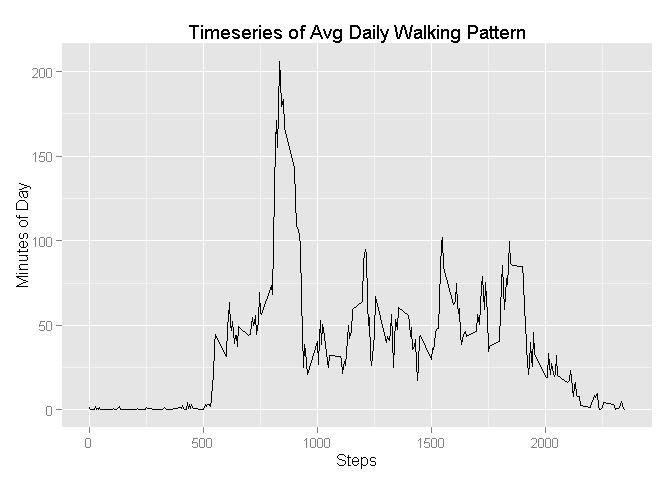

```r
ts <- aggregate(list(steps = d$steps), by = list(intervals = d$interval), FUN = mean, na.rm = TRUE)
ggplot(ts, aes(x = intervals, y = steps)) + geom_line() + labs(title = "Timeseries of Avg Daily Walking Pattern", y = "Minutes of Day", x = "Steps")
```

The following code chunk returns the 5 minute period with the highest average (mean) steps.

```r
ts$interval[ts$steps == max(ts$steps)]
```

```
## [1] 835
```